# MY472_assignment4

24 Jan 2024

# An Analysis of Multi Potential Biases in Police Stop and Searches in the UK

The github repo for this assignment can be found [here](https://github.com/matchakura/MY472assignment4)

### Data

The data is composed of more than 1 million records of stop-and-search provided by [police data](https://data.police.uk/). The data covered December 2020 to November 2023, while some missing values exist. In addition to the police data, a [census data of ethnicity](https://www.ons.gov.uk/census) will be used. After a general review of descriptive statistics of demographic characteristics, including age, gender, and ethical groups, the study will then focus on the ethical group and outcomes of stop-and-search.

By conducting normality test and T-test, the study aims to identify whether there are significant difference between outcomes of stop-and-search for different ethic groups groups.

## Analysis - Descriptive Statistics

### Age

#### Graph 1 & 2:

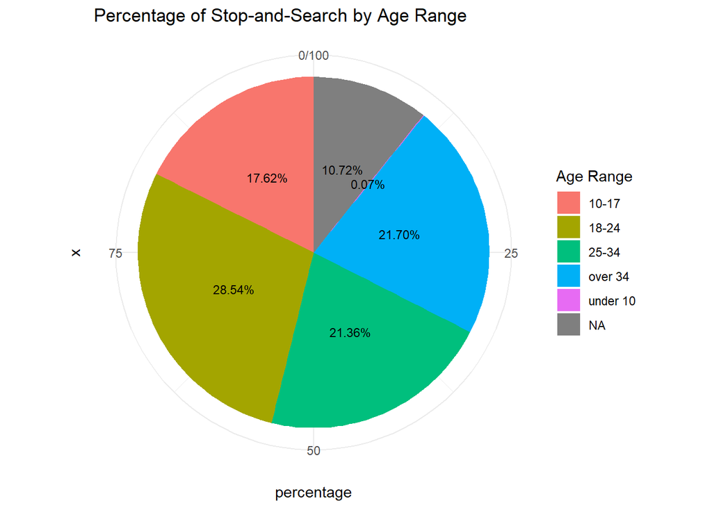

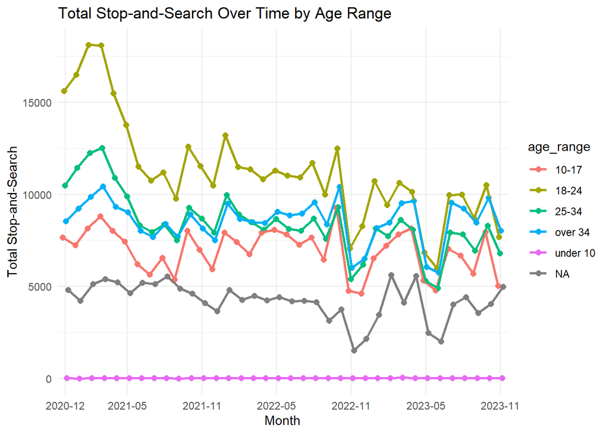

### Gender

#### Graph 3 & 4:

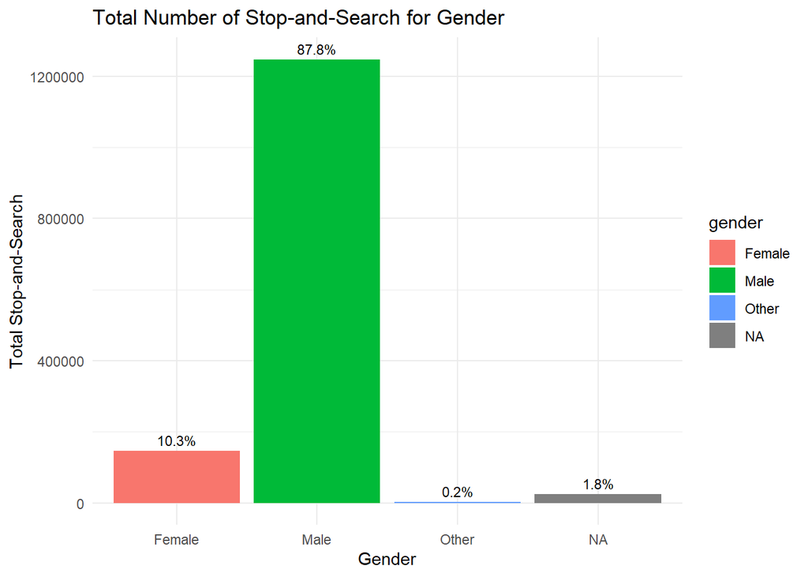

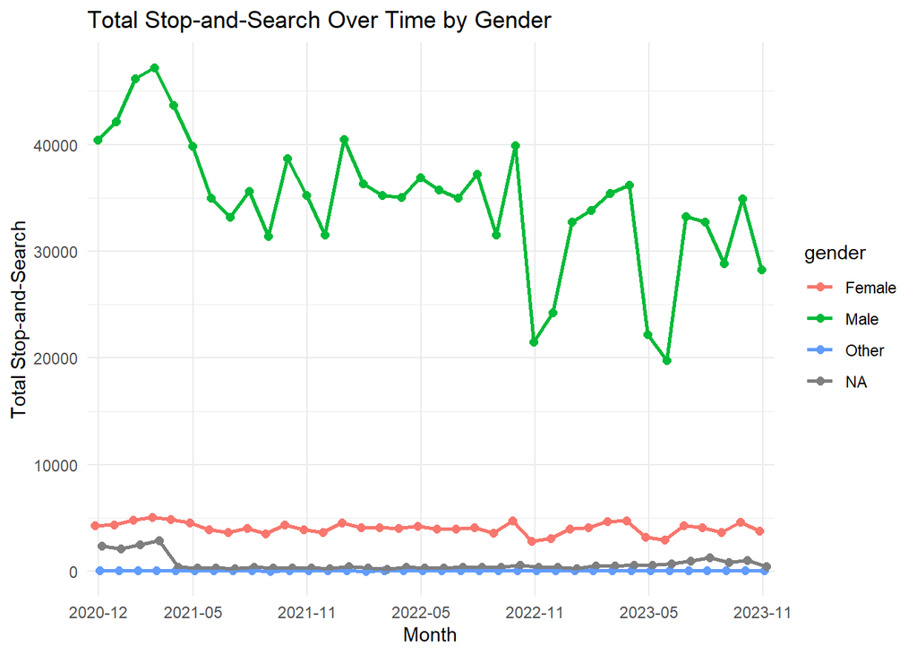

### Ethnicity

It is shown that While group has the highest rate of experiencing stop-and-search (60.9%), followed by Black (19.1%) and Asian (12.1%). In terms of percentage of outcomes by officer-defined ethnicity, it follows similar patterns across all ethic groups, and therefore a table is used to display numeric values.

Overall, no further action takes around 72.7% of outcome, with arrest being the second highest outcome. The arrest rate is highest in mixed group (18.7%), followed by 14.4% in Black, and lowest in Asian group (11.5%). In terms of Penalty rate, it is much lower in While group (0.9%) compared to 2.7% in Asian and 2.3% in black.

Given the observed difference in overall percentage of stop-and-search, in related to arrest and penalty rate, this study will explore the potential racial biases in stop-and-search actions.

#### Graph 3 & 4, Table 1:

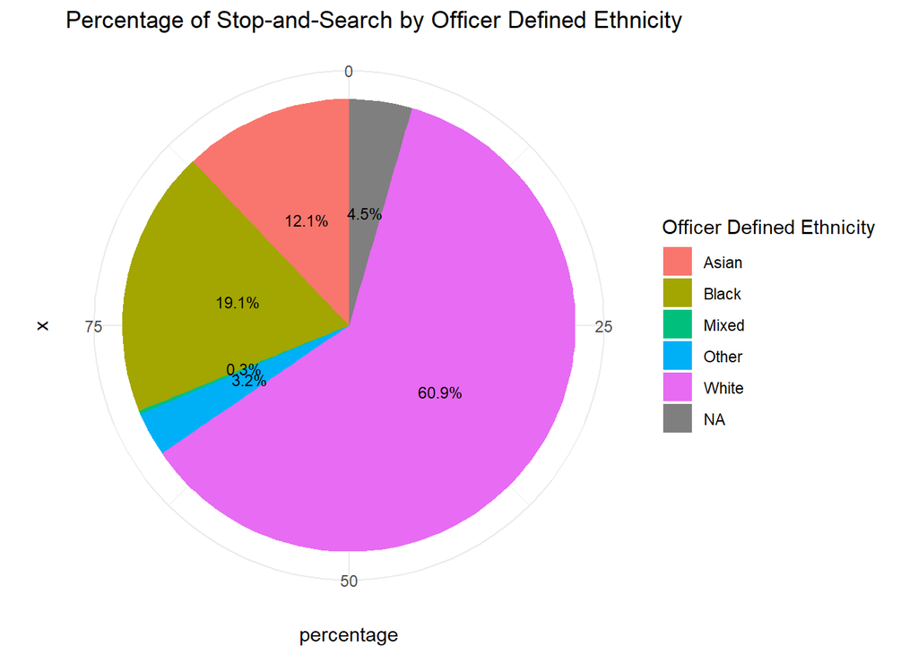

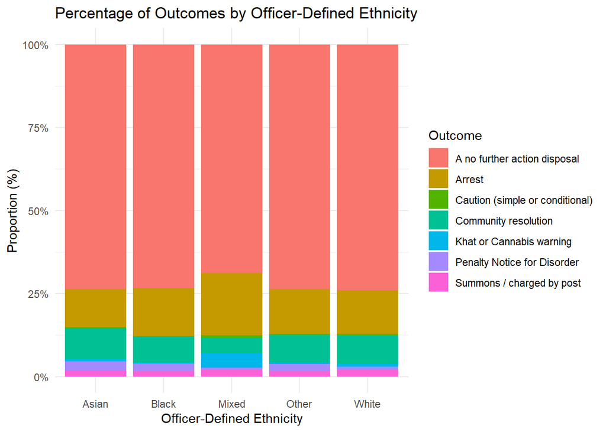

```
##
##
## Table: Proportion of Outcomes by Officer-Defined Ethnicity
##
## |officer_defined_ethnicity |A no further action disposal |Arrest |Caution (simple or conditional) |Community resolution |Khat or Cannabis warning |Penalty Notice for Disorder |Summons / charged by post |
## |:-------------------------|:----------------------------|:------|:-------------------------------|:--------------------|:------------------------|:---------------------------|:-------------------------|
## |Asian                     |73.7                         |11.5   |0.3                             |9.3                  |0.7                      |2.7                         |1.8                       |
## |Black                     |73.4                         |14.4   |0.1                             |7.8                  |0.4                      |2.3                         |1.6                       |
## |Mixed                     |68.8                         |18.7   |0.8                             |4.7                  |4.3                      |0.7                         |2.0                       |
## |Other                     |73.6                         |13.6   |0.3                             |8.3                  |0.5                      |2.2                         |1.6                       |
## |White                     |74.1                         |13.1   |0.4                             |8.5                  |1.0                      |0.9                         |2.0                       |
```

### Object of search

#### Table 2:

[output not shown]

## Inferential Statistics

### Measurement of biases

After standardization, the rate of stop-and-search is highest in Black group, followed by Others and Asian. Additionally, the graphs indicates a moderately decrease in two time-points, Nov 2022 and June 2023 across all ethnicity except for Mixed This could suggest a potential influence from social background (e.g., event, holiday, etc.) and further research could be helpful.

#### Graph 5:

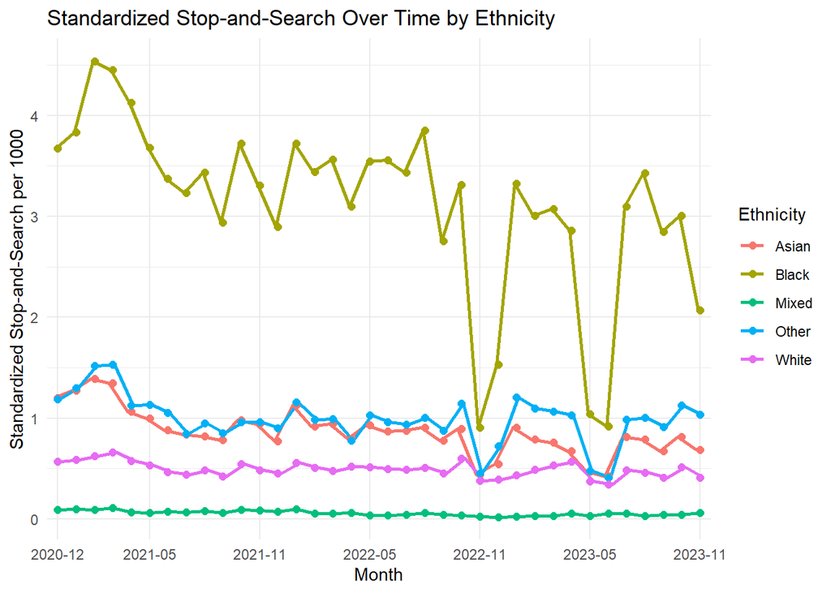

More specifically, this study examines four outcomes out of four nations. Caution, community resolution, penalty, and arrest were chosen, which represent different level of severity of outcomes. Mixed group was not included due to relatively small sample size. The results show that arrest has the highest rate after standardization, followed by community resolution and penalty. It indicates that arrest is the most common outcome of police stop-and-search, while police seldom use caution. While the percentage of the four outcomes are relatively close in Asian compared with Other ethic group, the Black group has the highest rate of receiving the all four outcomes, and the white receives the lowest.

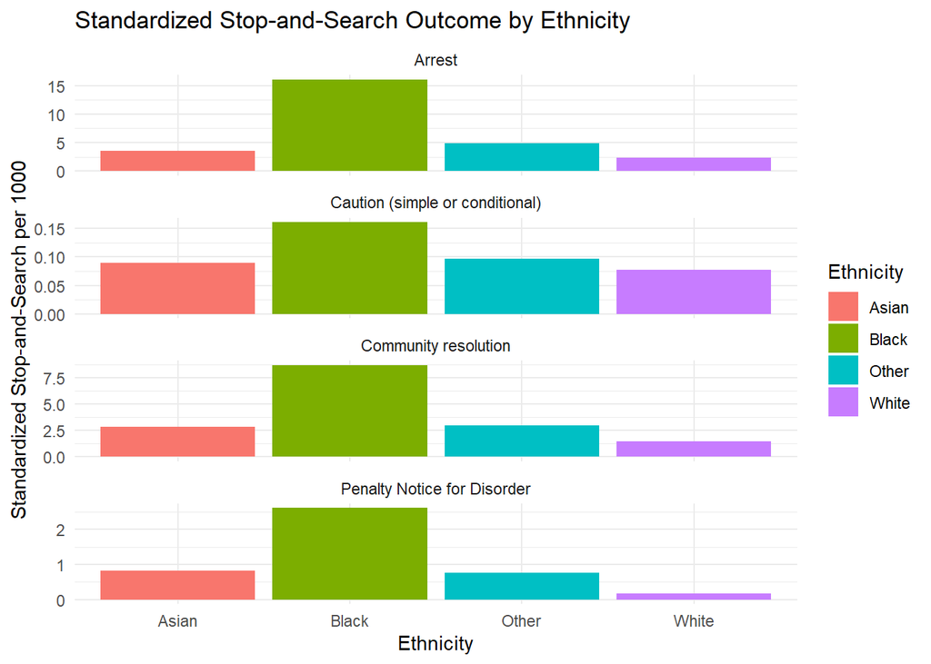

### Normality Test & T-test

However, the t-tests between the White and Black, Asian and White, Asian and Black are all not significant, indicating that the differences between the means of the two groups outcomes are not significantly different from each other.

Therefore, the results do not support the racial biases in stop-and-search outcomes among different ethical groups.

```
##
##  Shapiro-Wilk normality test
##
## data:  black_white
## W = 0.61192, p-value = 0.0003753
```

```
##
##  Shapiro-Wilk normality test
##
## data:  asian_black
## W = 0.6142, p-value = 0.000399
```

```
##
##  Shapiro-Wilk normality test
##
## data:  asian_white
## W = 0.59488, p-value = 0.0002369
```

```
##
##  Paired t-test
##
## data:  white and black
## t = -1.4241, df = 6, p-value = 0.2043
## alternative hypothesis: true mean difference is not equal to 0
## 95 percent confidence interval:
##  -36.606845   9.672489
## sample estimates:
## mean difference
##       -13.46718
```

```
##
##  Paired t-test
##
## data:  white and asian
## t = -1.4376, df = 6, p-value = 0.2006
## alternative hypothesis: true mean difference is not equal to 0
## 95 percent confidence interval:
##  -5.060927  1.314999
## sample estimates:
## mean difference
##       -1.872964
```

```
##
##  Paired t-test
##
## data:  asian and black
## t = -1.4206, df = 6, p-value = 0.2052
## alternative hypothesis: true mean difference is not equal to 0
## 95 percent confidence interval:
##  -31.564355   8.375928
## sample estimates:
## mean difference
##       -11.59421
```

## Appendix: All code in this assignment

```r
knitr::opts_chunk$set(echo = FALSE)
library(tidyverse)
library(RSQLite)
library(httr)
library(dplyr)
library(stringr)
library(lubridate)
library(tidyr)
library(knitr)
library(jsonlite)
library(ggplot2)
library(scales)
library(tools)
library(plotly)
library(stats)
library(mvnormtest )

# Initialize the api that returns the available dataset
api_endpoint <- "https://data.police.uk/api/crimes-street-dates"

# Make a GET request
get_response <- GET(url = api_endpoint)

# Check the response status
if (http_status(get_response)$category == "Success") {
  # Print the content of the response
  stop_and_search <- content(get_response, as = "parsed")

  # Initialize an empty list to store the extracted information
  date_forceid <- list()

  # Loop through each element in the list
  for (i in seq_along(stop_and_search)) {
    # Extract date information
    date_info <- stop_and_search[[i]]$date

    # Extract stop-and-search information
    force_id_info <- stop_and_search[[i]]$`stop-and-search`

    # Combine date and stop-and-search information into a list
    combined_info <- list(date = date_info, stop_and_search = force_id_info)

    # Append the combined information to the list
    date_forceid <- c(date_forceid, list(combined_info))
  }

  # Convert the list to a data frame using dplyr's bind_rows
  date_forceid_df <- bind_rows(lapply(date_forceid, as.data.frame))

} else {
  # Print an error message
  stop("Error in GET request:", http_status(get_response)$reason)
}

# Clean the variable name
colnames(date_forceid_df) <- gsub("^stop_and_search", "", colnames(date_forceid_df))
colnames(date_forceid_df) <- gsub("\\.", " ", colnames(date_forceid_df))

# Find the missing values across each month
date_forceid_df$missing_values_count <- rowSums(is.na(date_forceid_df))
date_forceid_df <- date_forceid_df %>%
  select(date, missing_values_count, everything())


# Find the missing value count for each force_id
missing_counts <- date_forceid_df %>%
  gather(key = "force_id", value = "value", -date, -missing_values_count) %>%
  group_by(force_id) %>%
  summarize(missing_count = sum(is.na(value))) %>%
   arrange(missing_count)

# Initialize lists to store data of stop and search, and to record missing values
sns_data <- list()

# Use force IDs with zero missing values
force_id <- missing_counts %>%
  pull(force_id) %>%
  str_trim() %>%        # Remove leading and trailing spaces
  str_replace_all(" ", "-")  # Replace spaces with hyphens

# Create a list of dates
start_date <- ym("2020-12")
end_date <- ym("2023-11")
# Create a list of dates (year and month only)
dates <- seq(ym("2020-12"), ym("2023-11"), by = "1 month") %>%
  format("%Y-%m")

# Loop through each police force id in each month
for (id in force_id){
  for (date in dates){
    # Construct the API endpoint
    force_endpoint <- paste0("https://data.police.uk/api/stops-force?force=", id, "&date=", date)
    # Make a GET request
    sns_response <- GET(url = force_endpoint)

    # Create a key for each force and date
    key <- paste(id, date, sep = "_")

    # Check the response status
    if (http_status(sns_response)$category == "Success") {
      # Parse the JSON response
      force_data <- fromJSON(rawToChar(sns_response$content), flatten = TRUE)

      # Check whether the response is empty
      if (length(force_data) > 0) {
        # Add found data to the list
        sns_data[[key]] <- force_data
      } else {
        # Add NA if missing values
        sns_data[[key]] <- NA
      }
    } else {
      # Print a warning message for unsuccessful requests
      warning(paste("Error in GET request for", date, "and force ID", id, ":", http_status(sns_response)$reason))
    }
  }
}
# Due to the reason of missing values, the number of columns might vary across different data frame
# Therefore, data will be cleaned before combining the lists

# Get all column names
column_names <- unique(unlist(lapply(sns_data, names)))

# Function to standardize the data frame in the list
cleaning_function <- function(df, column_names) {
  # If there are missing values, add NA
  missing_values <- setdiff(column_names, names(df))
  for (i in missing_values) {
    df[[i]] <- NA
  }
  # Match the order
  df <- df[, column_names]
  return(df)
}


# Apply cleaening function to each data frame
sns_data_cleaned <- lapply(sns_data, function(i) {
  if (is.data.frame(i) && nrow(i) > 0) {
    return(cleaning_function(i, column_names))
  } else {
    return(NA)
  }
})

# Combine the list of data frames
sns_df <- do.call(rbind, sns_data_cleaned)
#Remove columns with all NA values
sns_df <- sns_df %>% select_if(~any(!is.na(.)))

# Add force_id column
sns_df <- cbind(force_id = rownames(sns_df), sns_df)
# Clean the force_id column
sns_df <- sns_df %>%
  mutate(force_id = sub("_.*", "", force_id)) %>%
  mutate(force_id = gsub("-", " ", force_id))

# Select columns to keep
selected_columns <- c(
  "force_id",
  "age_range",
  "outcome",
  "involved_person",
  "gender",
  "datetime",
  "officer_defined_ethnicity",
  "object_of_search"
)

# Subset the dataframe to include only selected columns
sns_df <- sns_df %>%
  select(all_of(selected_columns))%>%
  filter(involved_person == TRUE)

# Now a dataframe with stop and search data during 2020.12 and 2023.11 has been created, which only includes values of interests

# Convert the "datetime" column to anobject
sns_df$datetime <- lubridate::ymd_hms(sns_df$datetime, tz = "UTC")

# Create a new column "month" with the format "YYYY-MM"
sns_df$month <- format(sns_df$datetime, "%Y-%m")

# Calculate total number of stop-and-search for each age_range
total_stop_search <- sns_df %>%
  group_by(age_range) %>%
  summarize(total_stop_search = n())

# Calculate the percentage of stop-and-search in each age range
total_stop_search <- total_stop_search %>%
  mutate(percentage = total_stop_search / sum(total_stop_search) * 100)

# Pie Chart
age_pie_chart <- ggplot(total_stop_search, aes(x = "", y = percentage, fill = age_range)) +
  geom_bar(stat = "identity", width = 1) +
  geom_text(aes(label = scales::percent(percentage / 100), y = percentage),
            position = position_stack(vjust = 0.5), size = 3) +
  coord_polar("y") +
  labs(title = "Percentage of Stop-and-Search by Age Range", fill = "Age Range") +
  theme_minimal() +
  theme(legend.position = "right")
```

```r
# Print the pie chart
print(age_pie_chart)


# Calculate total number of stop-and-search for each age_range across months
total_stop_search_monthly <- sns_df %>%
  group_by(month, age_range) %>%
  summarize(total_stop_search = n())

# Scatter Plot
age_scatter_plot <- ggplot(total_stop_search_monthly, aes(x = month, y = total_stop_search, color = age_range)) +
  geom_point(position = position_dodge(width = 0.5), size = 2) +
  geom_line(aes(group = age_range), position = position_dodge(width = 0.5), size = 1) +
  labs(title = "Total Stop-and-Search Over Time by Age Range", x = "Month", y = "Total Stop-and-Search") +
  theme_minimal() +
  theme(legend.position = "right") +
  scale_x_discrete(breaks = unique(total_stop_search_monthly$month)[c(1, 6, 12, 18, 24, 30,36)])

# Print the scatter plot
print(age_scatter_plot)

total_stop_search_gender <- sns_df %>%
  group_by(gender) %>%
  summarize(total_stop_search = n())

# Calculate the percentage of each gender group
total_stop_search_gender <- total_stop_search_gender %>%
  mutate(percentage = (total_stop_search / sum(total_stop_search)) * 100)

# Plotting the histogram
gender_histogram <- ggplot(total_stop_search_gender, aes(x = gender, y = total_stop_search, fill = gender)) +
  geom_bar(stat = "identity") +
  geom_text(aes(label = sprintf("%.1f%%", percentage)), vjust = -0.5, size = 3) +  # Add percentage labels
  labs(title = "Total Number of Stop-and-Search for Gender",
       x = "Gender",
       y = "Total Stop-and-Search") +
  theme_minimal()

# Display the plot
print(gender_histogram)

total_stop_search_monthly_gender <- sns_df %>%
  group_by(month, gender) %>%
  summarize(total_stop_search = n())

# Scatter Plot for gender with smaller dots and a geom line for each gender
gender_scatter_plot <- ggplot(total_stop_search_monthly_gender, aes(x = month, y = total_stop_search, color = gender)) +
  geom_point(position = position_dodge(width = 0.5), size = 2) +  # Adjust size as needed
  geom_line(aes(group = gender), position = position_dodge(width = 0.5), size = 1) +  # Add lines
  labs(title = "Total Stop-and-Search Over Time by Gender", x = "Month", y = "Total Stop-and-Search") +
  theme_minimal() +
  theme(legend.position = "right") +
  scale_x_discrete(breaks = unique(total_stop_search_monthly_gender$month)[c(1, 6, 12, 18, 24, 30, 36)])  # Specify which months to display

# Print the gender scatter plot
print(gender_scatter_plot)


# Calculate total number of stop-and-search for each officer_defined_ethnicity
total_stop_search_ethnicity <- sns_df %>%
  group_by(officer_defined_ethnicity) %>%
  summarize(total_stop_search = n())

# Calculate the percentage of stop-and-search in each officer_defined_ethnicity
total_stop_search_ethnicity <- total_stop_search_ethnicity %>%
  mutate(percentage = total_stop_search / sum(total_stop_search) * 100)

# Pie Chart
ethnicity_pie_chart <- ggplot(total_stop_search_ethnicity, aes(x = "", y = percentage, fill = officer_defined_ethnicity)) +
  geom_bar(stat = "identity", width = 1) +
  geom_text(aes(label = scales::percent(percentage / 100), y = percentage),
            position = position_stack(vjust = 0.5), size = 3) +  # Adjust size as needed
  coord_polar("y") +
  labs(title = "Percentage of Stop-and-Search by Officer Defined Ethnicity", fill = "Officer Defined Ethnicity") +
  theme_minimal() +
  theme(legend.position = "right")

# Print the officer_defined_ethnicity pie chart
print(ethnicity_pie_chart)


# Calculate the proportion of outcomes by officer-defined ethnicity
percentage_data <- sns_df %>%
  filter(!is.na(outcome), outcome != "", !is.na(officer_defined_ethnicity)) %>%
  group_by(officer_defined_ethnicity, outcome) %>%
  count() %>%
  group_by(officer_defined_ethnicity) %>%
  mutate(proportion = n / sum(n))

# Stacked bar chart
percentage_plot <- ggplot(percentage_data, aes(x = officer_defined_ethnicity, y = proportion, fill = outcome)) +
  geom_bar(stat = "identity") +
  labs(
    title = "Percentage of Outcomes by Officer-Defined Ethnicity",
    x = "Officer-Defined Ethnicity", y = "Proportion (%)",
    fill = "Outcome"
  ) +
  theme_minimal() +
  scale_y_continuous(labels = scales::percent_format())

# Print the plot
print(percentage_plot)

formatted_data <- percentage_data %>%
  mutate(across(where(is.numeric), ~sprintf("%.1f", . * 100)))

# Create the proportion_table with formatted values
percentage_table <- formatted_data %>%
  select(officer_defined_ethnicity, outcome, proportion) %>%
  tidyr::pivot_wider(names_from = outcome, values_from = proportion) %>%
  knitr::kable(caption = "Proportion of Outcomes by Officer-Defined Ethnicity")

# Print the formatted table
print(percentage_table)

census_ethnicity <- read.csv("Ethnic_group.csv") %>%
  rename(officer_defined_ethnicity = "Ethnic.group..20.categories.", ethnicity_census = "Observation") %>%
  filter(officer_defined_ethnicity %in% c("Asian", "Black", "Mixed", "White", "Other")) %>%
  mutate(ethnicity_census = as.numeric(ethnicity_census))

# Remove the NA row
standardized_ethnicity <- total_stop_search_ethnicity[-nrow(total_stop_search_ethnicity), ]

merged_data <- merge(standardized_ethnicity, census_ethnicity, by = "officer_defined_ethnicity")

merged_data <- merged_data %>%
  mutate(stand_sns = (total_stop_search / ethnicity_census) * 1000)


# Calculate total number of stop-and-search for each ethnicity across months
total_stop_search_monthly_ethnicity <- sns_df %>%
  group_by(month, officer_defined_ethnicity) %>%
  summarize(total_stop_search = n())

# Merge with census data
merged_data_ethnicity <- merge(total_stop_search_monthly_ethnicity, census_ethnicity, by = "officer_defined_ethnicity")

# Calculate standardized rate per 1,000 population
merged_data_ethnicity <- merged_data_ethnicity %>%
  mutate(stand_sns = (total_stop_search / ethnicity_census) * 1000)

# Line graph
ethnicity_scatter_graph <- ggplot(merged_data_ethnicity, aes(x = month, y = stand_sns, color = officer_defined_ethnicity)) +
  geom_line(aes(group = officer_defined_ethnicity), position = position_dodge(width = 0.5), size = 1) +
  geom_point(size = 2) +
  labs(title = "Standardized Stop-and-Search Over Time by Ethnicity",
       x = "Month", y = "Standardized Stop-and-Search per 1000",
       color = "Ethnicity") +
  theme_minimal() +
  theme(legend.position = "right") +
  scale_x_discrete(breaks = unique(total_stop_search_monthly$month)[c(1, 6, 12, 18, 24, 30,36)])
```

```r
# Print the scatter graph
print(ethnicity_scatter_graph)

# Apply standardization to "n" column in percentage_data
percentage_data_standardized <- percentage_data %>%
  left_join(census_ethnicity, by = "officer_defined_ethnicity") %>%
  mutate(stand_n = (n / ethnicity_census) * 1000)

# Filter out the outcome
percentage_data_filtered <- percentage_data_standardized %>%
  filter(outcome != "A no further action disposal")%>%
  filter(outcome != "Summons / charged by post")%>%
  filter(outcome != "Khat or Cannabis warning")%>%
  filter(officer_defined_ethnicity != "Mixed")


# Grouped bar chart with facet_wrap
grouped_bar_chart <- ggplot(percentage_data_filtered, aes(x = officer_defined_ethnicity, y = stand_n, fill = officer_defined_ethnicity)) +
  geom_bar(stat = "identity", position = "dodge") +
  labs(
    title = "Standardized Stop-and-Search Outcome by Ethnicity",
    x = "Ethnicity", y = "Standardized Stop-and-Search per 1000",
    fill = "Ethnicity"
  ) +
  theme_minimal() +
  theme(legend.position = "right") +
  facet_wrap(~outcome, scales = "free_y", ncol = 1)

# Print the grouped bar chart with facet_wrap
print(grouped_bar_chart)


# Combine select and rename operations
t_test_df <- percentage_data_standardized %>%
  select(officer_defined_ethnicity, outcome, stand_n) %>%
  rename(ethnicity = officer_defined_ethnicity, stand_sns = stand_n)


# Summary the data
#percentage_data_standardized %>%
  #summary(ethnicity, type = "mean_sd")

# Normality test
black_white <- with(t_test_df,
        stand_sns[ethnicity == "Black"] - stand_sns[ethnicity == "White"])
shapiro.test(black_white)

asian_black <- with(t_test_df,
        stand_sns[ethnicity == "Black"] - stand_sns[ethnicity == "Asian"])
shapiro.test(asian_black)

asian_white <- with(t_test_df,
        stand_sns[ethnicity == "Asian"] - stand_sns[ethnicity == "White"])
shapiro.test(asian_white)

# All the p-values are greater than 0.05, indicating that the distribution of the differences (d) are not significantly different from normal distribution. Therefore, we can assume the normality.

white <- subset(t_test_df,  ethnicity == "White", stand_sns, drop = TRUE)
black <- subset(t_test_df,  ethnicity == "Black", stand_sns, drop = TRUE)
asian <- subset(t_test_df,  ethnicity == "Asian", stand_sns, drop = TRUE)


res1 <- t.test(white, black, paired = TRUE)
res2 <- t.test(white, asian, paired = TRUE)
res3 <- t.test(asian, black, paired = TRUE)

res1
res2
res3

# this chunk generates the complete code appendix.
# eval=FALSE tells R not to run (``evaluate'') the code here (it was already run before).
```